# HW 01: Install software, edit and push README

Graphical Analysis of Biological Data

By the end of this assignment, you should achieve the following.

- have a GitHub account;
- installed Git, R, and R Studio; and
- edited your README.md file with Markdown.
- use Git to push your README.md file to GitHub.

*These achievements are part of Learning Outcomes 5 and 6.*

Click on any blue text to visit the external website.

**Problems?** If you have a problem at any point during this assignment, please email me (mtaylor@semo.edu) with *specific details* of the problem. The more detailed your explanation of your problem, the quicker I can help you. *Help me help you!*

The grading rubric is at the end of this document.

## Part 1 of 2

### Register for a free GitHub account

Register for a *free* [GitHub account](http://www.github.com), and then, fill out [this form](https://semo-gabd.shinyapps.io/485info/) with your name, GitHub user name, and other requested information. I am using this information *only* for course management. If all goes as I have hoped, you have already done this.

- Follow the advice given in [Chapter 5](http://happygitwithr.com/github-acct.html) to register for your free GitHub account. *Do not pay for private repositories for this course.*
- Optional: complete this [GitHub tutorial](https://guides.github.com/activities/hello-world/), using your GitHub account (e.g., `https://github.com/<your_github_username>`). You do not have to complete this tutorial now but I recommend that you complete it sometime to help you understand Git.

### Software Installation

[Happy Git with R](http://happygitwithr.com/), written by Dr. Jenny Bryan, gives instructions for installing the software we will use for this course. Follow the steps below. Most chapters are *very* brief.

- Read [Chapter 1](http://happygitwithr.com/big-picture.html) and [Chapter 4](http://happygitwithr.com/installation-pain.html) for some background information and mental preparation.
- Follow [Chapter 6](http://happygitwithr.com/install-r-rstudio.html) to install R and R Studio. The preview version mentioned in the chapter is a reasonably stable development version, which will have the latest versions. For the current stable release, you can download the [desktop version.](https://www.rstudio.com/products/rstudio/#Desktop) Either is OK for this course.
- Launch RStudio. You should see a screen that looks similar to the image below, although the console window may use the entire left side.

[figure not shown]

- In the console window, type `x <- 2 * 4` and press Enter. (`<-` is the less than symbol, followed by a dash.) Nothing will happen. Now, type `x` and press Enter , and you should see `[1] 8`. That indicates success! You have installed R and RStudio.
- **NOTE:** Whenever you quit RStudio, you might be asked if you want to save your workspace. Just say no! R project files automatically restore your R workspace when you open them.
- Follow the [Chapter 7 instructions](http://happygitwithr.com/install-git.html) *carefully* to install Git for your computer platform. You may have to follow instructions in [Appendix A](http://happygitwithr.com/shell.html) to intall a command shell or command line tools. Take your time. It is not difficult but you must follow the instructions carefully.
- **Mac users:** You *must* have the command line tools installed for R Studio to work with GitHub. If you do not get the prompt to install the command line tools described in Chapter 7 or Appendix A, you can install them following [these instructions](http://osxdaily.com/2014/02/12/install-command-line-tools-mac-os-x/). You must have an active internet connection.
  1. Open `terminal` from the `/Applications/Utilities` folder.
  2. Type the following command into the terminal and press the Enter key.

  ```
  xcode-select --install
  ```

  3. Click the `Install` button in the dialog box. Wait for the installation to finish.
- Complete [Chapter 8](http://happygitwithr.com/hello-git.html) to configure Git. You do not need to configure a default editor yet because you will do most of your work in R Studio. If you did download a text editor to use, you can tell Git to use your editor. You can find specific configurations from [Software Carpentry](http://swcarpentry.github.io/git-novice/02-setup/). If you use Atom, for example, configure git with

```
git config --global core.editor "atom --wait"
```

### Claim Your Course Repository

I have created a public GitHub repository for your use during the course. I am the owner but you are a collaborator, which means you can edit (push) files in this repository. You should also have received an invitation to join this repository. All students can see all of the student repositories, including yours, but only you can push files to your repository.

First, go to https://github.com/gabd-students to verify that you can see a repository in your name. It will be in the format `lastname_firstname`. You will see repositories for other students, too. If you do not see a repository with your name, send me an email telling me you do not see the repository.

If you do see your directory, then do *all* of the following steps.

1. Make a folder on your computer for your work for this course. You can put it anywhere but keep track where you put it. For example, you can make a folder called “bi485” and put it inside `~/Documents` or `C:\Documents` folder. **I recommend that you keep the folder name short and without spaces.** For Mac users, ~ is the tilde mark, not a dash. It represents the Documents folder on your computer.
2. Launch RStudio (if it is not still running from above).
3. Choose `File > New Project...`
4. Choose `Version Control`, then `Git`.

[figure not shown]

6. Fill in the dialog box with the relevant information.
- Enter `https://github.com/gabd-students/lastname_firstname` for the repository URL, substituting your last name, an underscore, then your first name.
- Enter `lastname_firstname` for the project directory name. It may appear automatically when you fill in the first blank.
- Enter the directory you created at the start of this exercise as the main folder (e.g., `~/Documents/bi485` or `C:\Documents\bi485`). The dialog should look something like this. Mac users must include the tilde symbol.

[figure not shown]

7. Click on the `Create Project` button. R Studio will clone the GitHub repository on your computer in the folder you specified.
- If prompted, enter the GitHub user name and password you used when you created your GitHub account. Your screen should look similar to that shown on the next page.
- **Remember the location of this repository and project file.** The project file has the `.Rproj` extension. You will do all of your homework in this folder, using this project file.
- **For all future assignments in this course, double-click on your `.Rproj` project file to start RStudio.** This will ensure that RStudio knows where to find your scripts and data.
- I will refer to this repository on your computer as the **local repository** or **local repo.** The equivalent repository stored on GitHub is called the **remote repo.**
8. R Studio should look similar to this. Notice the list of files in the lower right window. Click once on the `README.md` file. It will open in the upper left window of R Studio. You will edit this file in Part 2 of this assignment.

[figure not shown]

*Pipit the Cat cannot spell, apparently.*

### Optional steps

- Download this [RStudio Cheatsheet](https://github.com/rstudio/cheatsheets/raw/master/rstudio-ide.pdf) and keep it handy. It will help you learn to use RStudio quickly and efficiently. Other cheatsheets are [also available.](https://www.rstudio.com/resources/cheatsheets/) I will provide links to the most relevant sheets as we proceed but feel free to download any that you want. I have laminated sets at home and at work.
- [Chapter 9](http://happygitwithr.com/git-client.html) is optional. You will use RStudio most often to interact with Git and GitHub for this course. Later, you may find that a standalone Git client is helpful, especially as your Git-Fu grows stronger. I sometimes use [Git Kraken](https://www.gitkraken.com/git-client) because, well…[kraken.](https://en.wikipedia.org/wiki/Kraken)
- Read other chapters in [Happy Git With R](http://happygitwithr.com/) at your leisure. We may use part or all of some chapters in future exercises.

## Part 2 of 2

### Introduction to Markdown

Markdown is a way of formatting plain text with bold, italics, links to web pages, and more. You will use markdown extensively during this course.

- Complete this [markdown tutorial.](https://commonmark.org/help/tutorial/) You can also download this [markdown cheatsheet.](https://github.com/adam-p/markdown-here/wiki/Markdown-Cheatsheet)
- Open the Rproj file you created in Part 1 (if not still open). Click on the README.md file in the file list in the lower right panel of RStudio. If you do not see a list of files, first click on the “Files” tab (or press `ctrl-5`). If you see a list of files, but do not see the README.md file, then click on the “Git” tab of the upper right panel (or press `ctrl-9`). Click the `Pull` button with the downward-pointing green arrow. That should pull the README.md file from your remote repo to your local repo. *If you still do not see the README.md file, contact me immediately.*

### Edit the README file

README files generally describe what is in the repository. For this assignment, your README.md file should tell a little about you and also reflect who you are as a person. You will also use various `markdown` commands to practice using them.

If none of the requirements seem familiar, then take (or re-take) the [markdown tutorial](https://commonmark.org/help/tutorial/) and reference the [markdown cheatsheet.](https://github.com/adam-p/markdown-here/wiki/Markdown-Cheatsheet) Also, the `Help` menu in R Studio has a `Markdown Quick Reference` help item. `Help > Cheatsheets` has a link to an R Markdown cheatsheet PDF.

| Name | Breed (not pure) | Age (years) |
| --- | --- | --- |
| Pipit | Ragamuffin or Ragdoll? | 2 |
| Lynx | Lynx-point Tabby | 2.5 |
| Jet | Egyptian Mau | 13 |

You will use markdown in later exercises so get comfortable with it.

### Commit and push the README file to your GitHub account.

The following steps will `push` your README.md file to GitHub for the world to see. Get used to this process because you will use it. A lot. You’ll complete an exercise in the near future that will help you to better understand Git and GitHub. For now, just follow these steps carefully.

1. First, just be sure your local repository is up-to-date with your remote repository, choose `Tools > Version Control > Pull Branches` from the menu. You should get a dialog box that says already up-to-date. Close the dialog.
2. Choose `Tools > Version Control > Commit` from the menu. In the future, you can also use the appropriate keyboard shortcut, such as <ctrl-option-m> on the Mac, which I think is <ctrl-alt-m> in Windows.
3. Click the checkboxes next to any files that are listed in the upper left. Type “Initial commit.” in the blank box in the upper right. Your screen should look similar to Pipit’s. Only files that have changed will appear so you may see only the README.md file.

[figure not shown]

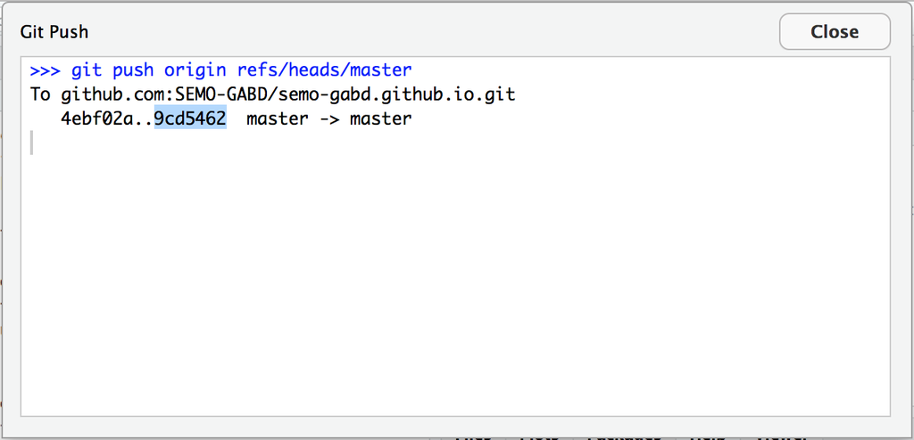

## Grading Rubric

#### Part 1

This part is all or none.

| No work: 0 | Needs work: 1 | Satisfactory: 2 | Excellent: 3 |
| --- | --- | --- | --- |
| Did not install software. | Does not apply. | Does not apply. | Installed all software. |
| Did not claim repository. | Does not apply. | Does not apply. | Claimed repository. |

#### Part 2

| No work: 0 | Needs work: 1 | Satisfactory: 2 | Excellent: 3 |
| --- | --- | --- | --- |
| Did not edit and push README to remote repo. | At least one task not completed. | All tasks completed but at least one not completed as directed. | Completed all tasks correctly. |

*et Voilà*